# Mini-Project

Grace Wagner and Nathanael Kovscek

2023-03-17

## Front Matter Including Task 1

```r
# Load necessary libraries
library(tidyverse)
library(ggplot2)
library(lubridate)

#Part 1
library(readxl)
CODGames2_mp <- read_excel("data/CODGames2_mp.xlsx")
```

## Task 2

Explore 6 variables (at least 1 categorical and 1 quantitative).

Identify: - variable and type of variable #DONE - types of values the variable can take #DONE - amount of missing data within variable #DONE - summary statistics #DONE - visualization #DONE - write a few sentences to describe what you have learned about the variable #NEED TO FINISH

If Categorical: - make a table of possible values and include counts or proportions #DONE - make an appropriate plot to show the distribution of values #DONE

if Quantitative: - Include some basic summary stats like the mean, median, standard deviation, min, max, etc. #DONE - make an appropriate plot to show the distribution of values #DONE

```r
#Variable 1: Eliminations
#type
typeof(CODGames2_mp$Eliminations)
```

```
## [1] "double"
```

```r
#range
range(CODGames2_mp$Eliminations)
```

```
## [1]  2 39
```

```r
#missing value
sum(is.na(CODGames2_mp$Eliminations))
```

```
## [1] 0
```

```r
#summary stats
CODGames2_mp %>%
  summarize(
    mean = mean(Eliminations),
    median = median(Eliminations),
    sd = sd(Eliminations),
    min = min(Eliminations),
    max = max(Eliminations)
  )
```

```
## # A tibble: 1 × 5
##    mean median    sd   min   max
##   <dbl>  <dbl> <dbl> <dbl> <dbl>
## 1  15.1     14  6.13     2    39
```

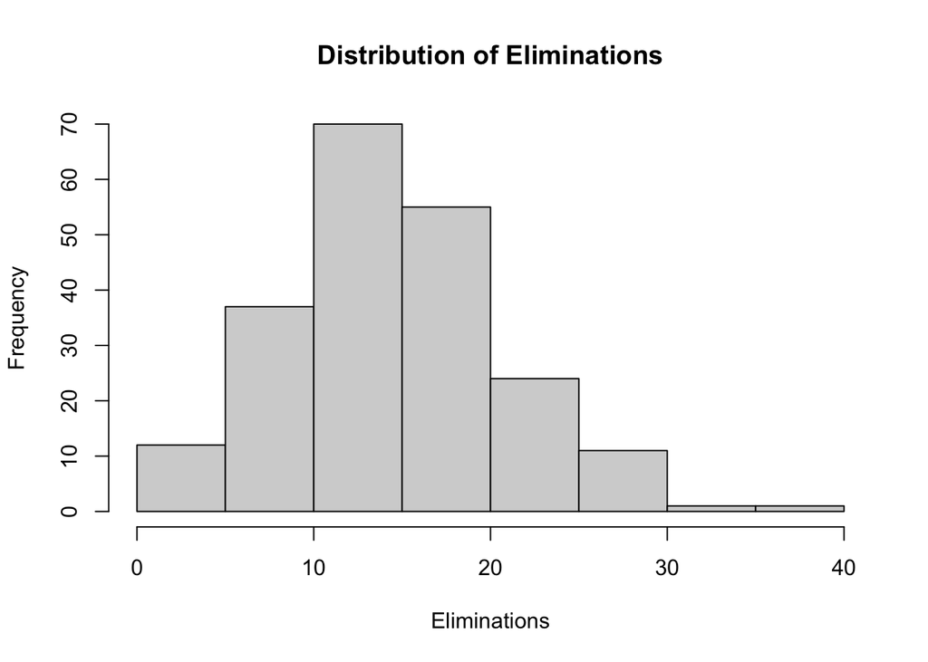

```r
#plot
hist(CODGames2_mp$Eliminations,
     xlab = "Eliminations",
     main = "Distribution of Eliminations")
```

```r
#Variable 2: Deaths
typeof(CODGames2_mp$Deaths)
```

```
## [1] "double"
```

```r
range(CODGames2_mp$Deaths)
```

```
## [1]  4 42
```

```r
sum(is.na(CODGames2_mp$Deaths))
```

```
## [1] 0
```

```r
CODGames2_mp %>%
  summarize(
    mean = mean(Deaths),
    median = median(Deaths),
    sd = sd(Deaths),
    min = min(Deaths),
    max = max(Deaths)
  )
```

```
## # A tibble: 1 × 5
##    mean median    sd   min   max
##   <dbl>  <dbl> <dbl> <dbl> <dbl>
## 1  15.0     15  5.13     4    42
```

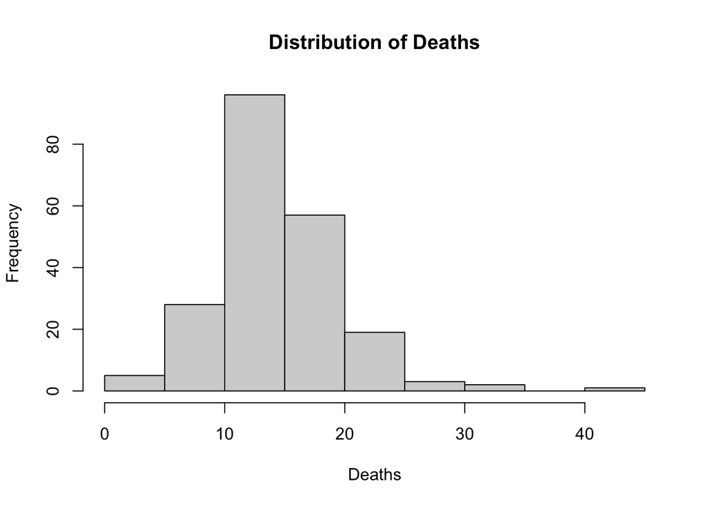

```r
hist(CODGames2_mp$Deaths,
     xlab = "Deaths",
     main = "Distribution of Deaths")
```

```r
#Variable 3: Score
typeof(CODGames2_mp$Score)
```

```
## [1] "double"
```

```r
range(CODGames2_mp$Score)
```

```
## [1]  100 7315
```

```r
sum(is.na(CODGames2_mp$Score))
```

```
## [1] 0
```

```r
CODGames2_mp %>%
  summarize(
    mean = mean(Score),
    median = median(Score),
    sd = sd(Score),
    min = min(Score),
    max = max(Score)
  )
```

```
## # A tibble: 1 × 5
##    mean median    sd   min   max
##   <dbl>  <dbl> <dbl> <dbl> <dbl>
## 1 2945.   2770 1465.   100  7315
```

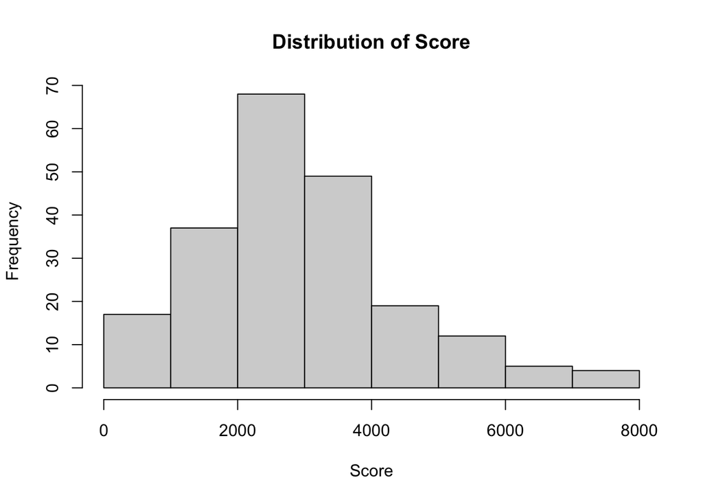

```r
hist(CODGames2_mp$Score,
     xlab = "Score",
     main = "Distribution of Score")
```

```r
#Variable 4: Damage
typeof(CODGames2_mp$Damage)
```

```
## [1] "double"
```

```r
range(CODGames2_mp$Damage)
```

```
## [1]  56 960
```

```r
sum(is.na(CODGames2_mp$Damage))
```

```
## [1] 0
```

```r
CODGames2_mp %>%
  summarize(
    mean = mean(Damage),
    median = median(Damage),
    sd = sd(Damage),
    min = min(Damage),
    max = max(Damage)
  )
```

```
## # A tibble: 1 × 5
##    mean median    sd   min   max
##   <dbl>  <dbl> <dbl> <dbl> <dbl>
## 1  415.    397  166.    56   960
```

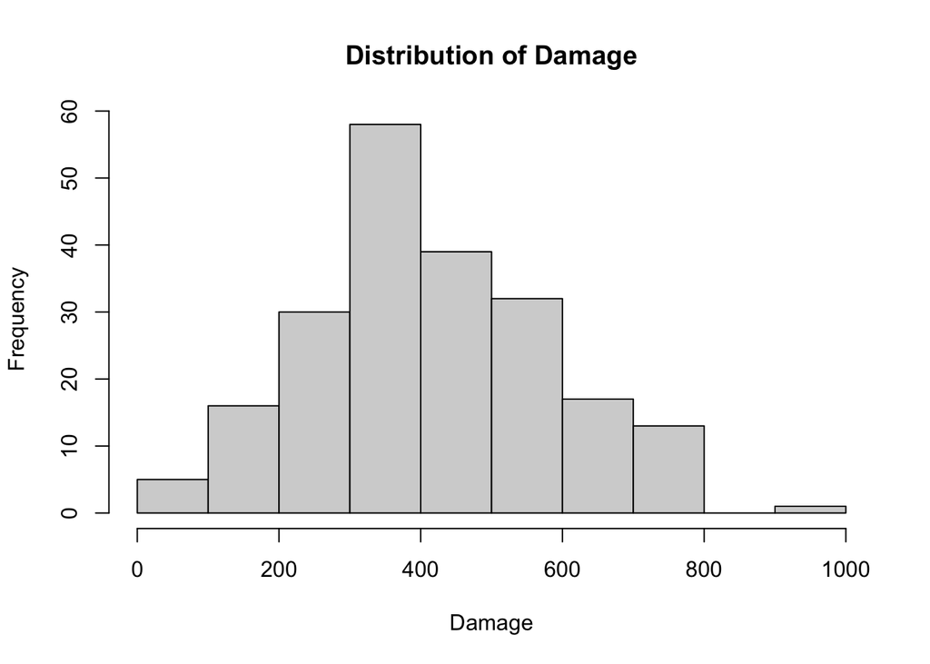

```r
hist(CODGames2_mp$Damage,
     xlab = "Damage",
     main = "Distribution of Damage")
```

```r
#Variable 5: TotalXP
typeof(CODGames2_mp$TotalXP)
```

```
## [1] "double"
```

```r
range(CODGames2_mp$TotalXP)
```

```
## [1]  1935 43816
```

```r
sum(is.na(CODGames2_mp$TotalXP))
```

```
## [1] 0
```

```r
CODGames2_mp %>%
  summarize(
    mean = mean(TotalXP),
    median = median(TotalXP),
    sd = sd(TotalXP),
    min = min(TotalXP),
    max = max(TotalXP)
  )
```

```
## # A tibble: 1 × 5
##     mean median    sd   min   max
##    <dbl>  <dbl> <dbl> <dbl> <dbl>
## 1 11975.  10328 6167.  1935 43816
```

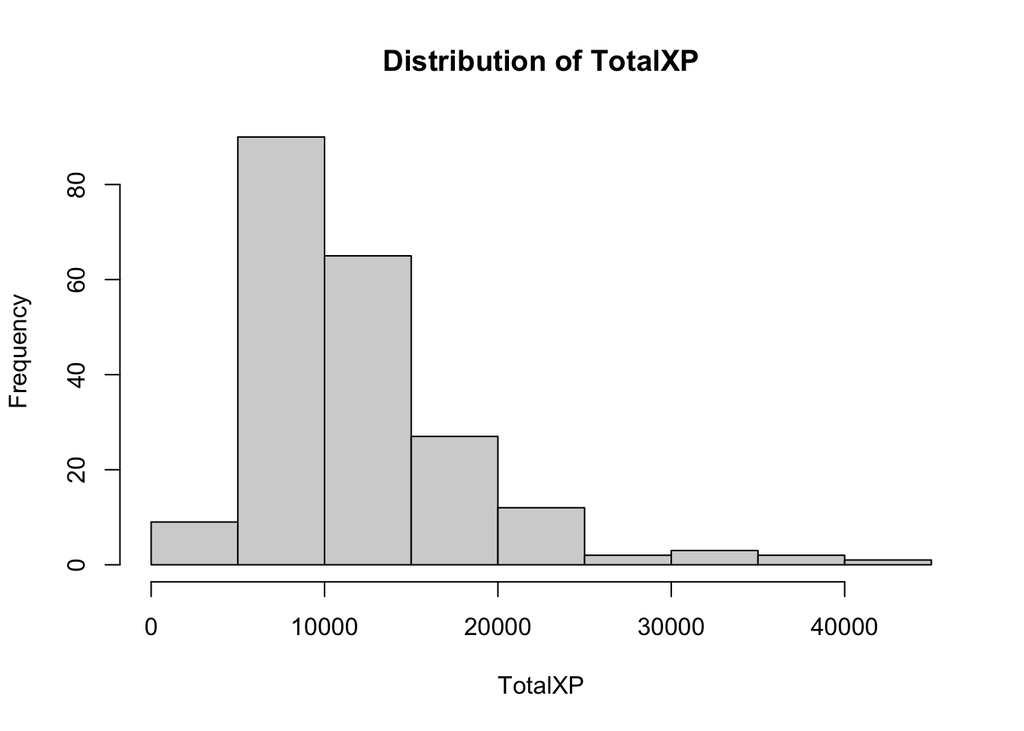

```r
hist(CODGames2_mp$TotalXP,
     xlab = "TotalXP",
     main = "Distribution of TotalXP")
```

```r
#Number 6 Candidates (or remove a quantitative one and add both categorical)

#Variable 6: PrimaryWeapon
typeof(CODGames2_mp$PrimaryWeapon)
```

```
## [1] "character"
```

```r
unique(CODGames2_mp$PrimaryWeapon)
```

```
## [1] "M16"           "MP5"           "AK-47"         "Krig 6"
## [5] "QBZ-83"        "Pelington 703" "FFAR 1"        "Type 63"
## [9] "MG 82"
```

```r
sum(is.na(CODGames2_mp$PrimaryWeapon))
```

```
## [1] 0
```

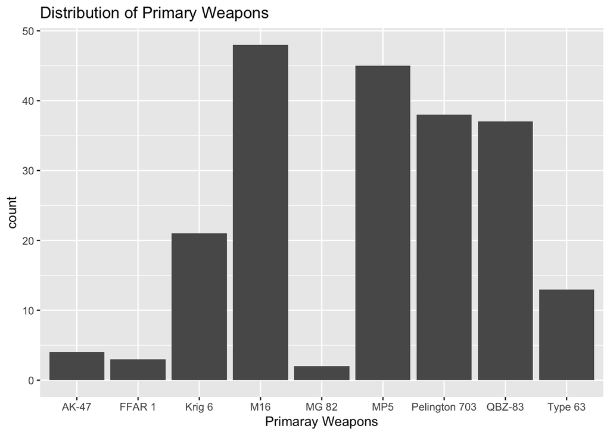

```r
tableWeapons <- CODGames2_mp %>%
  group_by(PrimaryWeapon) %>%
  summarize(N = n())

ggplot(CODGames2_mp, aes(PrimaryWeapon)) +
  geom_bar() +
  labs(title = "Distribution of Primary Weapons", x = "Primaray Weapons")
```

```r
#Variable 6: Choice #Has NA values
typeof(CODGames2_mp$Choice)
```

```
## [1] "character"
```

```r
unique(CODGames2_mp$Choice)
```

```
##  [1] "Miami Strike"      "Moscow"            "Yamantau"
##  [4] "Drive-In"          "Collateral Strike" "Raid"
##  [7] "WMD"               "Standoff"          "Crossroads Strike"
## [10] "Deprogram"         "Nuketown '84"      "Jungle"
## [13] "Rush"              "Zoo"               "Slums"
## [16] "Echelon"           "Garrison"          "Cartel"
## [19] "Express"           "The Pines"         "Apocalypse"
## [22] "Diesel"            "Amerika"           "Checkmate"
## [25] "Hijacked"          NA
```

```r
sum(is.na(CODGames2_mp$Choice))
```

```
## [1] 1
```

```r
CODGames2_mp %>%
  group_by(Choice) %>%
  summarize(N = n())
```

```
## # A tibble: 26 × 2
##    Choice                N
##    <chr>             <int>
##  1 Amerika               3
##  2 Apocalypse            7
##  3 Cartel                7
##  4 Checkmate             7
##  5 Collateral Strike    12
##  6 Crossroads Strike    15
##  7 Deprogram             5
##  8 Diesel               15
##  9 Drive-In             11
## 10 Echelon               4
## # … with 16 more rows
```

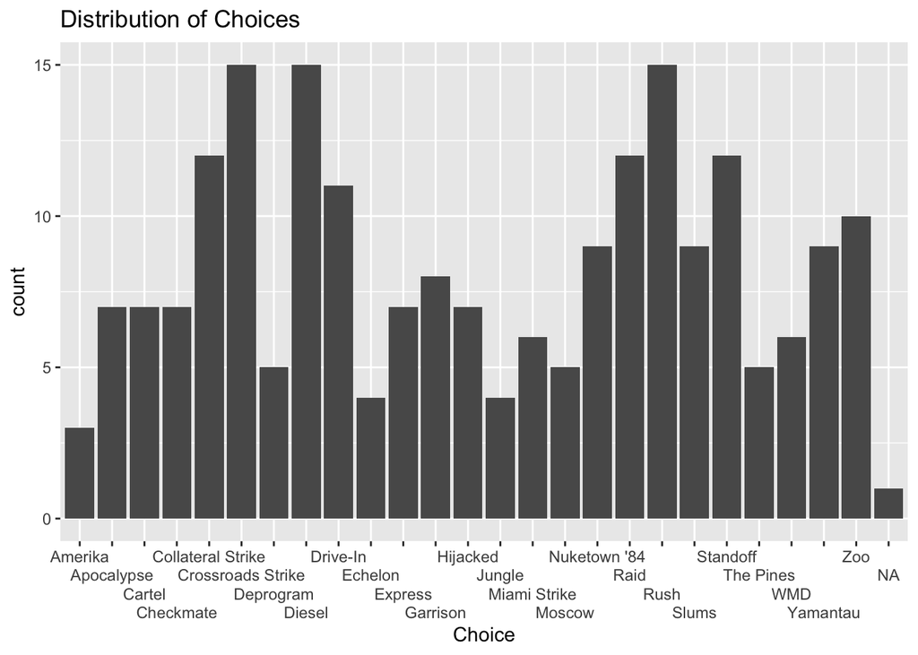

```r
ggplot(CODGames2_mp, aes(Choice)) +
  geom_bar() +
  scale_x_discrete(guide = guide_axis(n.dodge = 4)) +
  labs(title = "Distribution of Choices", xlab = "Choices")
```

## Task 3

All of our questions are regarding what the variables mean. Here they are:

- What aspects of the game play into the variable Score? How can one score high? How does it differ from TotalXP?
- What would cause the variable “Choice” - which is the choice of map in which the game is played - to have an NA value?
- What is the relationship between Map1, Map2, Choice, and MapVote?
- What does the ratio mean in the variable MapVote?
- What are the different GameTypes?
- What does the Results table represent and does the meaning change among game types?

## Task 4

### Part 1

Is the player’s performance, as quantified by the amount of experience points gained (TotalXP variable) changing over time?

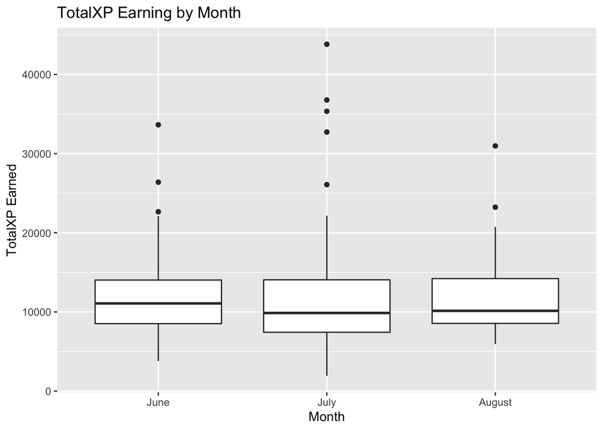

```r
# Create a new table with TotalXP, Date, and then year, month, day derived from Date
# the lubridate package is loaded in with tidyverse

xp <- CODGames2_mp %>%
  select("Date", "TotalXP") %>%
  mutate(year = year(CODGames2_mp$Date),
         month = month.name[month(CODGames2_mp$Date)],
         day = day(CODGames2_mp$Date)
         )

# Use fct_inorder to order boxplots by month
ggplot(data = xp, mapping = aes( x = fct_inorder(month), y = TotalXP)) +
  geom_boxplot() +
  labs(title = "TotalXP Earning by Month",
       x = "Month",
       y = "TotalXP Earned")
```

*Assessment:*

It does not appear that there is any improvement whatsoever across the three months in which the user played the game. In fact, the median value of XP earned in a day during a given month is less in both July and August as compared to June. Arguably, the user’s performance worsened.

However, there are numerous variables at play here. Game play could have affected the TotalXP value. Additionally, the user might decide that, once his performance with a particular weapon reaches a certain level, he wants to use a different weapon. So, while he apparently is not earning more XP over time, that does not necessarily mean that he is becoming worse at the game.

The one final note is that the user might not have played as much from month to month. Such variability in game play would also affect our assessment.

### Part 2

question I was thinking we could ask: which primary weapon (or choice, but choice has NA values) resulted in the most deaths/elimintaions/totalXp

What is the relationship between deaths and eliminations over time?